# Individual Project

Martin Hofbauer

2019-05-26

# Introduction

The assignment is to predict house prices in King County, USA, using the following kaggle dataset: Initially, the required lackages and the data will be loaded, then - if necessary - some data cleaning and adjustments will be done and an EDA will be created. Afterwards, a baseling will be made and evaluated, and based on the performance, the author then decides on how to further proceed.

# Data Reading and Preparation

## Loading the required Packages

[output not shown]

## Loading the Data

The dataset is offered in two separated files, one for the training and another one for the test.

## Initial Information of the Datasets

Training and Test are mostly similar, only that the target variable is not available in test (as it has to be predicted there). As can be seen, a couple of transformations have to be performed as some variables don’t have the correct data type.

```
## [1] 0
```

```
## [1] 0
```

```
## 'data.frame':    17277 obs. of  21 variables:
##  $ id           : num  9.18e+09 4.64e+08 2.22e+09 6.16e+09 6.39e+09 ...
##  $ date         : Factor w/ 372 levels "1/10/2015","1/12/2015",..: 211 331 290 20 226 223 94 34 76 294 ...
##  $ price        : num  225000 641250 810000 330000 530000 ...
##  $ bedrooms     : int  3 3 4 4 4 4 4 3 4 3 ...
##  $ bathrooms    : num  1.5 2.5 3.5 1.5 1.75 3.5 3.25 2.25 2.5 1.5 ...
##  $ sqft_living  : int  1250 2220 3980 1890 1814 3120 4160 1440 2250 2540 ...
##  $ sqft_lot     : int  7500 2550 209523 7540 5000 5086 47480 10500 6840 9520 ...
##  $ floors       : num  1 3 2 1 1 2 2 1 2 1 ...
##  $ waterfront   : int  0 0 0 0 0 0 0 0 0 0 ...
##  $ view         : int  0 2 2 0 0 0 0 0 0 0 ...
##  $ condition    : int  3 3 3 4 4 3 3 3 3 3 ...
##  $ grade        : int  7 10 9 7 7 9 10 8 9 8 ...
##  $ sqft_above   : int  1250 2220 3980 1890 944 2480 4160 1130 2250 1500 ...
##  $ sqft_basement: int  0 0 0 0 870 640 0 310 0 1040 ...
##  $ yr_built     : int  1967 1990 2006 1967 1951 2008 1995 1983 1987 1959 ...
##  $ yr_renovated : int  0 0 0 0 0 0 0 0 0 0 ...
##  $ zipcode      : int  98030 98117 98024 98155 98115 98115 98072 98023 98058 98115 ...
##  $ lat          : num  47.4 47.7 47.6 47.8 47.7 ...
##  $ long         : num  -122 -122 -122 -122 -122 ...
##  $ sqft_living15: int  1260 2200 2220 1890 1290 1880 3400 1510 2480 1870 ...
##  $ sqft_lot15   : int  7563 5610 65775 8515 5000 5092 40428 8125 7386 6800 ...
```

```
## 'data.frame':    4320 obs. of  20 variables:
##  $ id           : num  6.41e+09 6.05e+09 1.60e+07 2.52e+09 8.56e+09 ...
##  $ date         : Factor w/ 323 levels "1/12/2015","1/13/2015",..: 99 48 96 288 52 52 218 262 252 105 ...
##  $ bedrooms     : int  3 3 2 3 3 3 3 3 3 5 ...
##  $ bathrooms    : num  2.25 1.75 1 2.75 2.5 1 2.5 1 2.5 2.5 ...
##  $ sqft_living  : int  2570 1370 1200 3050 2320 1090 2300 1280 3160 3150 ...
##  $ sqft_lot     : int  7242 9680 9850 44867 3980 3000 3060 9656 13603 9134 ...
##  $ floors       : num  2 1 1 1 2 1.5 1.5 1 2 1 ...
##  $ waterfront   : int  0 0 0 0 0 0 0 0 0 0 ...
##  $ view         : int  0 0 0 4 0 0 0 0 0 0 ...
##  $ condition    : int  3 4 4 3 3 4 3 4 3 4 ...
##  $ grade        : int  7 7 7 9 8 8 8 6 8 8 ...
##  $ sqft_above   : int  2170 1370 1200 2330 2320 1090 1510 920 3160 1640 ...
##  $ sqft_basement: int  400 0 0 720 0 0 790 360 0 1510 ...
##  $ yr_built     : int  1951 1977 1921 1968 2003 1929 1930 1959 2003 1966 ...
##  $ yr_renovated : int  1991 0 0 0 0 0 2002 0 0 0 ...
##  $ zipcode      : int  98125 98074 98002 98040 98027 98117 98115 98058 98019 98056 ...
##  $ lat          : num  47.7 47.6 47.3 47.5 47.5 ...
##  $ long         : num  -122 -122 -122 -122 -122 ...
##  $ sqft_living15: int  1690 1370 1060 4110 2580 1570 1590 1340 3050 1990 ...
##  $ sqft_lot15   : int  7639 10208 5095 20336 3980 5080 3264 8808 9232 9133 ...
```

## First steps

In order not to apply all transformations and feature engineering twice (one for training and one for test), the datasets are joined. Furthermore, the id will be saved separately in order to lateron grant easy readability. Additionally, as no price is given in the test set, 0 will be imputed to be abled to make the join.

```
##         date           price            bedrooms        bathrooms
##  6/23/2014:  142   Min.   :      0   Min.   : 1.000   Min.   :0.500
##  6/25/2014:  131   1st Qu.: 220000   1st Qu.: 3.000   1st Qu.:1.750
##  6/26/2014:  131   Median : 384000   Median : 3.000   Median :2.250
##  7/8/2014 :  127   Mean   : 431877   Mean   : 3.373   Mean   :2.116
##  4/27/2015:  126   3rd Qu.: 580000   3rd Qu.: 4.000   3rd Qu.:2.500
##  3/25/2015:  123   Max.   :7700000   Max.   :33.000   Max.   :8.000
##  (Other)  :20817
##   sqft_living       sqft_lot           floors        waterfront
##  Min.   :  370   Min.   :    520   Min.   :1.000   Min.   :0.000000
##  1st Qu.: 1430   1st Qu.:   5040   1st Qu.:1.000   1st Qu.:0.000000
##  Median : 1910   Median :   7618   Median :1.500   Median :0.000000
##  Mean   : 2080   Mean   :  15099   Mean   :1.494   Mean   :0.007547
##  3rd Qu.: 2550   3rd Qu.:  10685   3rd Qu.:2.000   3rd Qu.:0.000000
##  Max.   :13540   Max.   :1651359   Max.   :3.500   Max.   :1.000000
##
##       view          condition        grade          sqft_above
##  Min.   :0.0000   Min.   :1.00   Min.   : 3.000   Min.   : 370
##  1st Qu.:0.0000   1st Qu.:3.00   1st Qu.: 7.000   1st Qu.:1190
##  Median :0.0000   Median :3.00   Median : 7.000   Median :1560
##  Mean   :0.2343   Mean   :3.41   Mean   : 7.658   Mean   :1789
##  3rd Qu.:0.0000   3rd Qu.:4.00   3rd Qu.: 8.000   3rd Qu.:2210
##  Max.   :4.0000   Max.   :5.00   Max.   :13.000   Max.   :9410
##
##  sqft_basement       yr_built     yr_renovated        zipcode
##  Min.   :   0.0   Min.   :1900   Min.   :   0.00   Min.   :98001
##  1st Qu.:   0.0   1st Qu.:1951   1st Qu.:   0.00   1st Qu.:98033
##  Median :   0.0   Median :1975   Median :   0.00   Median :98065
##  Mean   : 291.7   Mean   :1971   Mean   :  84.46   Mean   :98078
##  3rd Qu.: 560.0   3rd Qu.:1997   3rd Qu.:   0.00   3rd Qu.:98118
##  Max.   :4820.0   Max.   :2015   Max.   :2015.00   Max.   :98199
##
##       lat             long        sqft_living15    sqft_lot15
##  Min.   :47.16   Min.   :-122.5   Min.   : 399   Min.   :   651
##  1st Qu.:47.47   1st Qu.:-122.3   1st Qu.:1490   1st Qu.:  5100
##  Median :47.57   Median :-122.2   Median :1840   Median :  7620
##  Mean   :47.56   Mean   :-122.2   Mean   :1987   Mean   : 12758
##  3rd Qu.:47.68   3rd Qu.:-122.1   3rd Qu.:2360   3rd Qu.: 10083
##  Max.   :47.78   Max.   :-121.3   Max.   :6210   Max.   :871200
##
```

# EDA

## Plot of Target variable

As one can see, the price is right skewed. This can be expected as only few people can afford expensive houses. Therefore, this variable will be normalized.

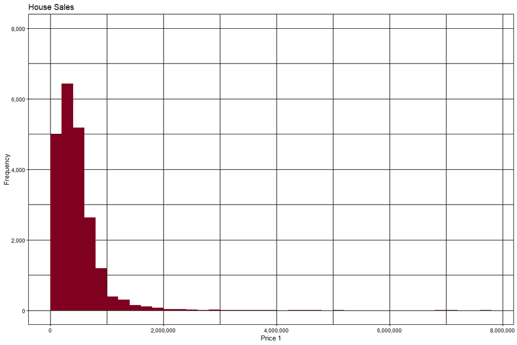

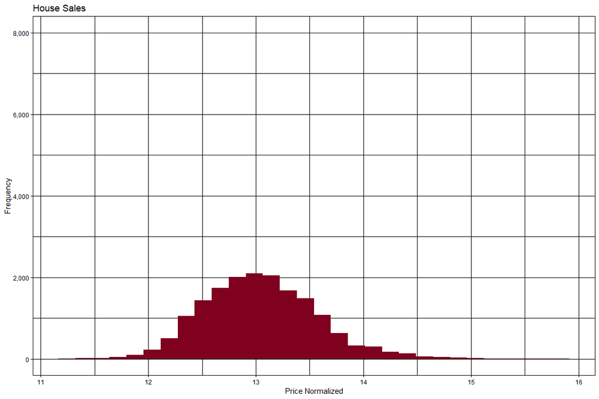

## Map

[interactive chart not shown]

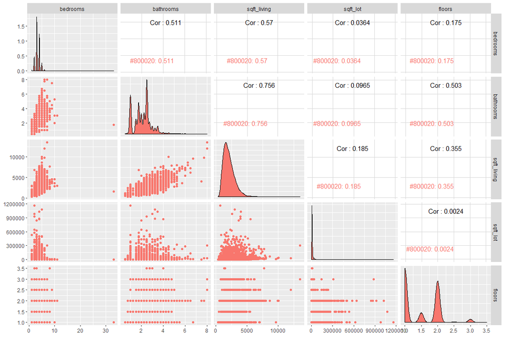

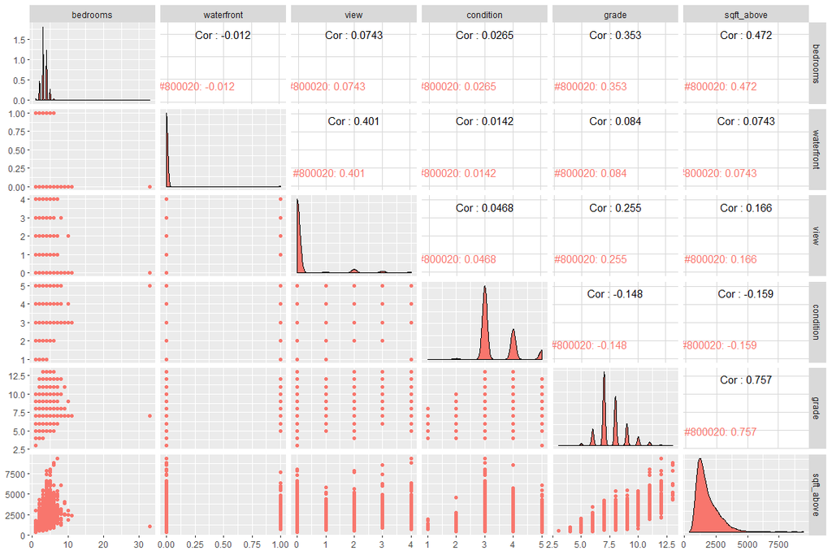

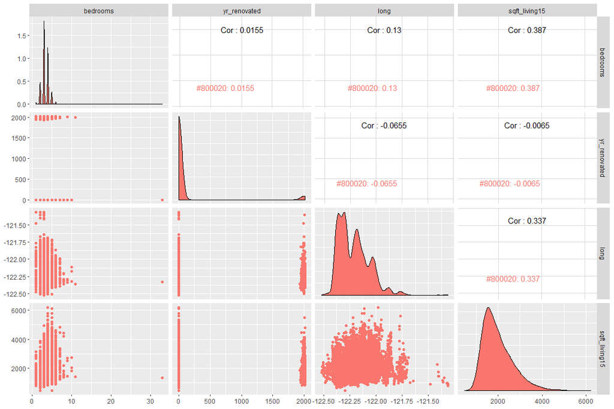

## Corr Plot

```
## There are 19 numeric variables
```

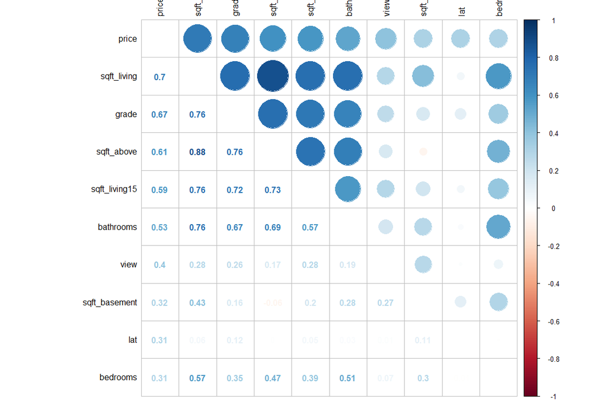

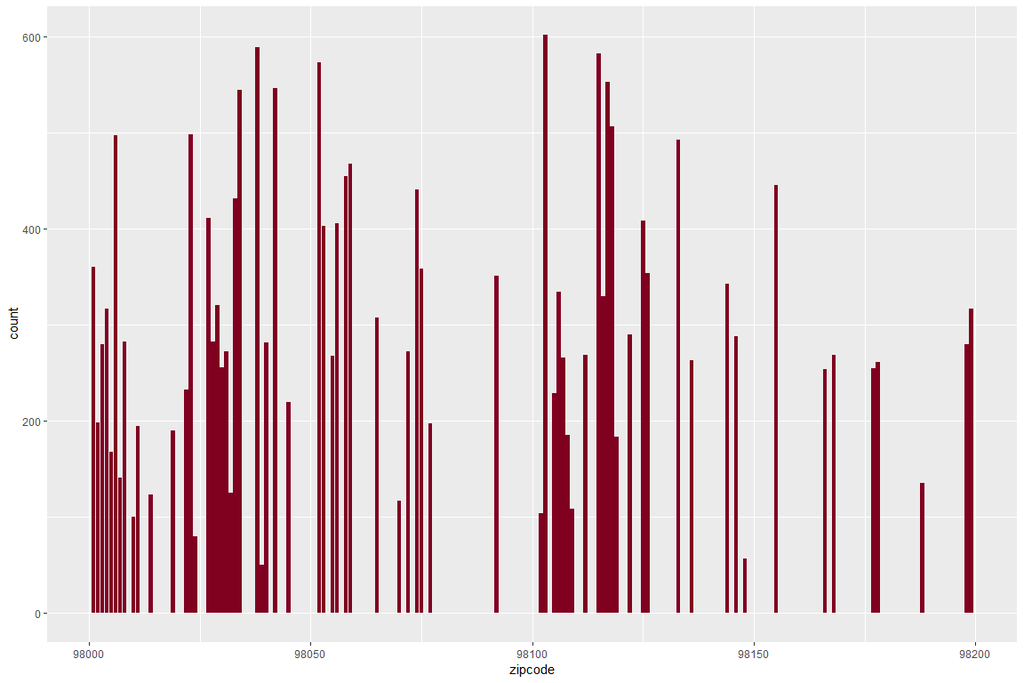

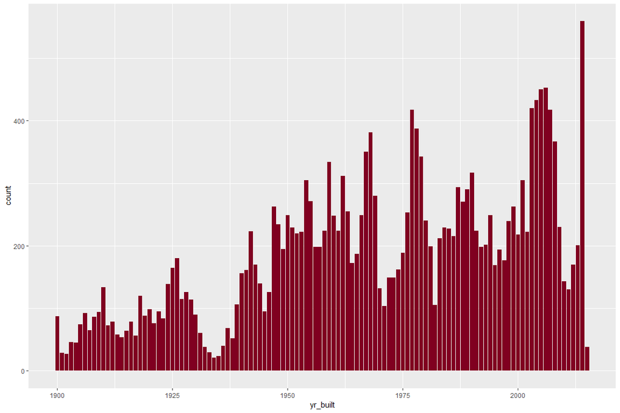

[figure not shown]

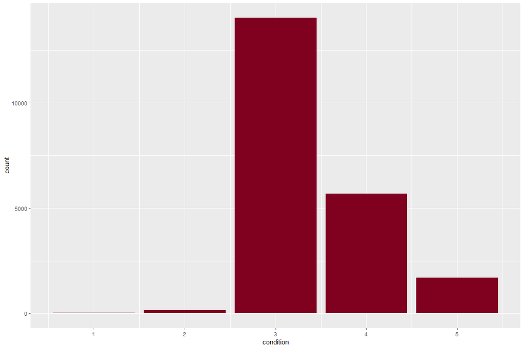

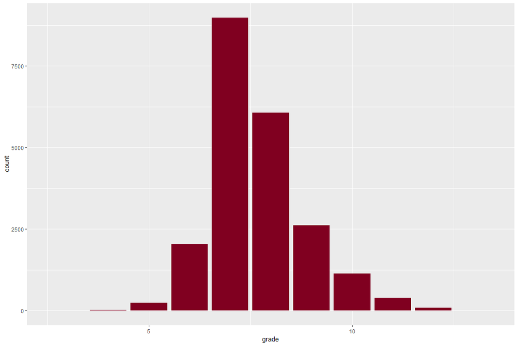

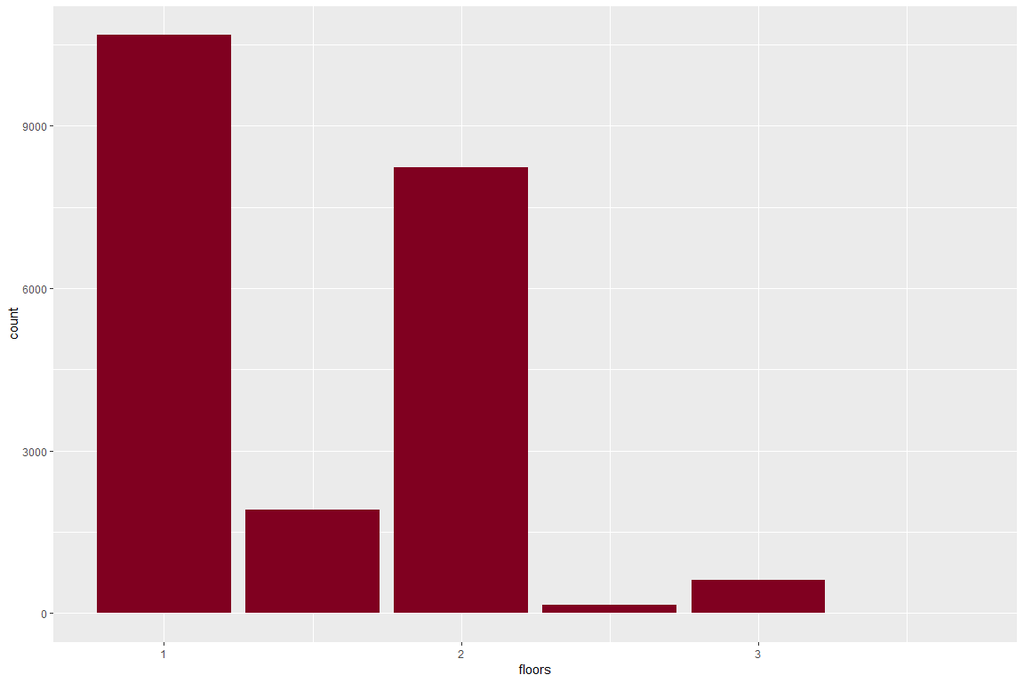

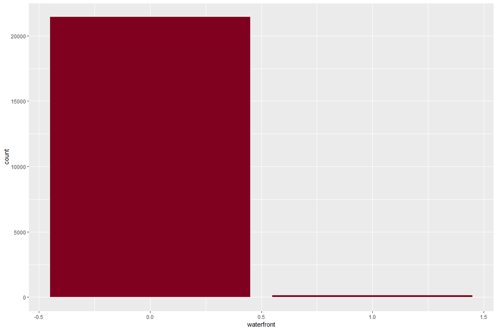

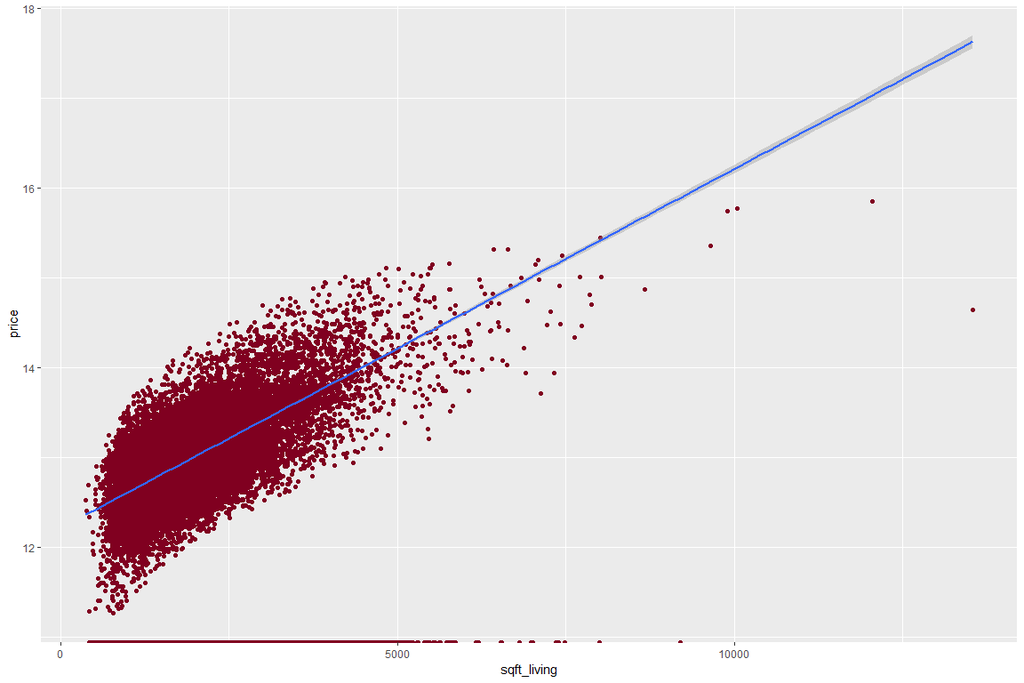

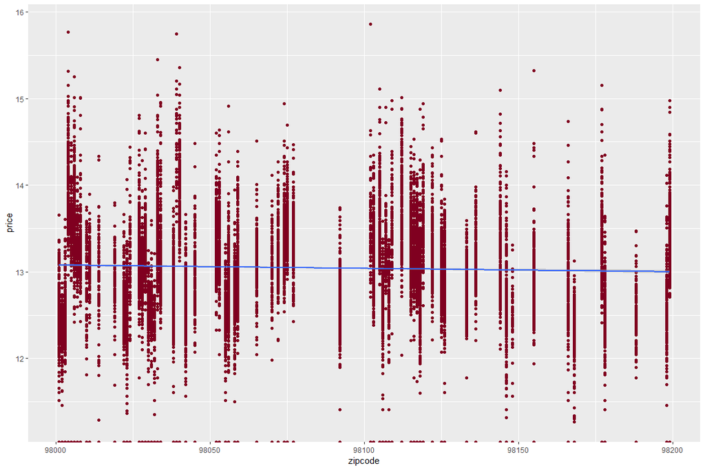

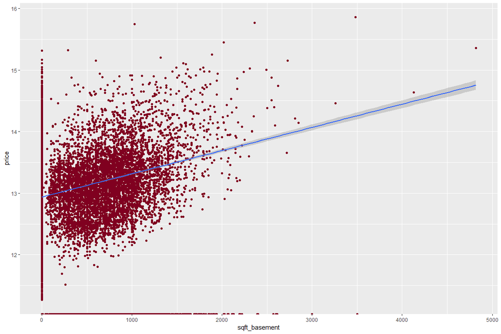

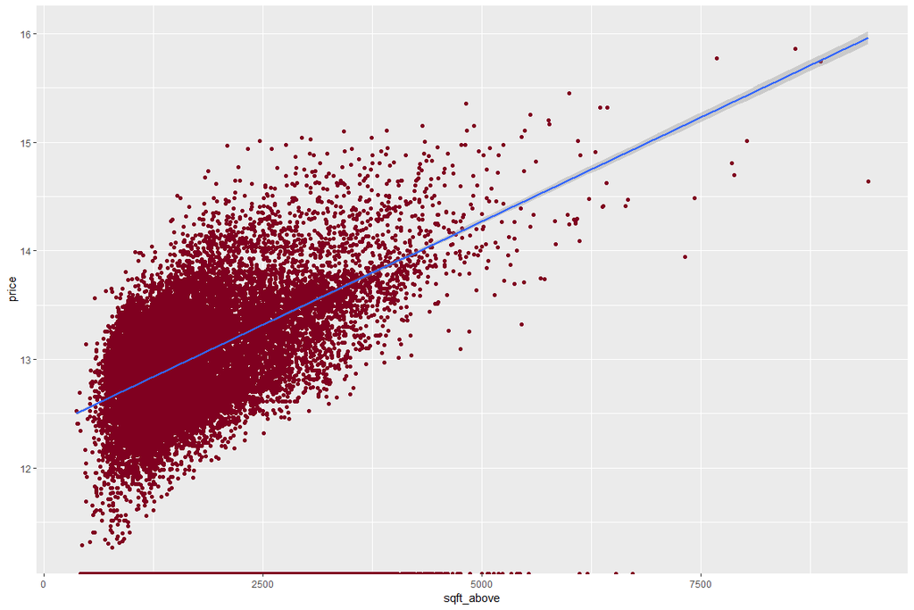

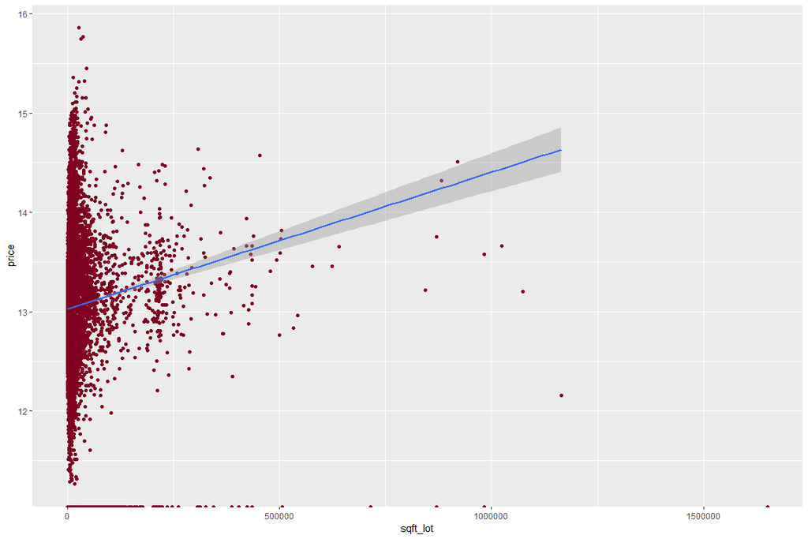

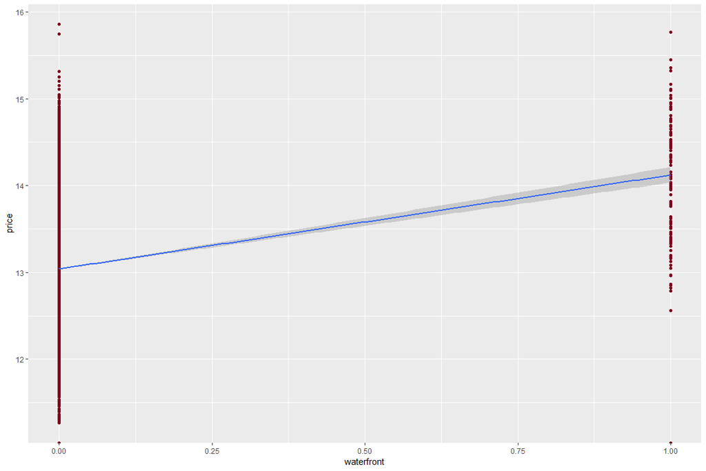

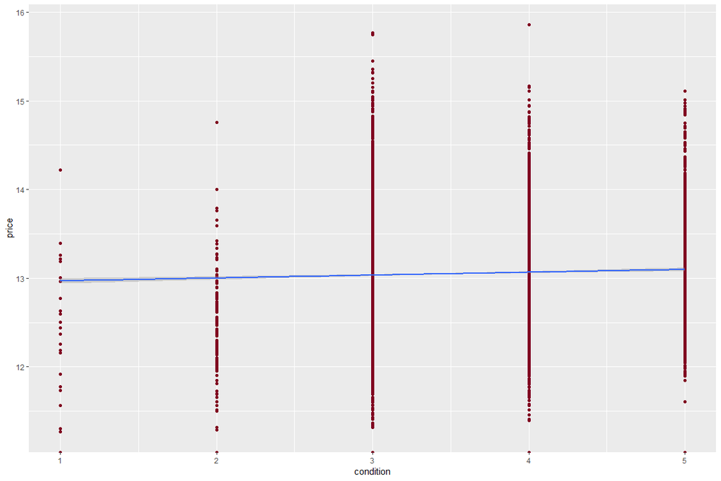

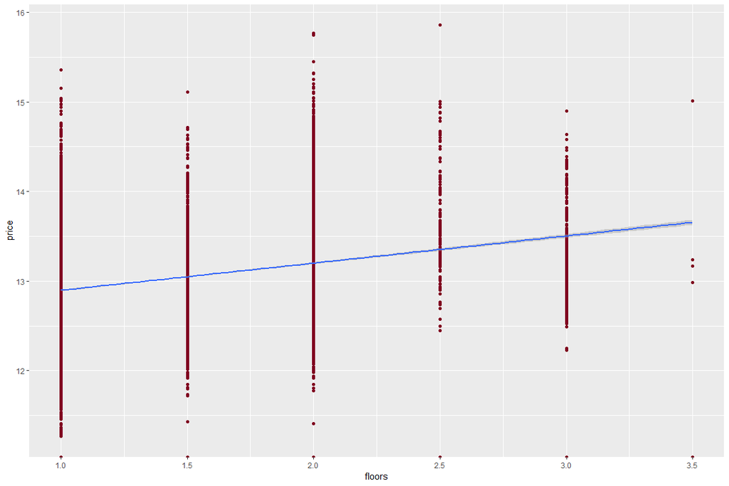

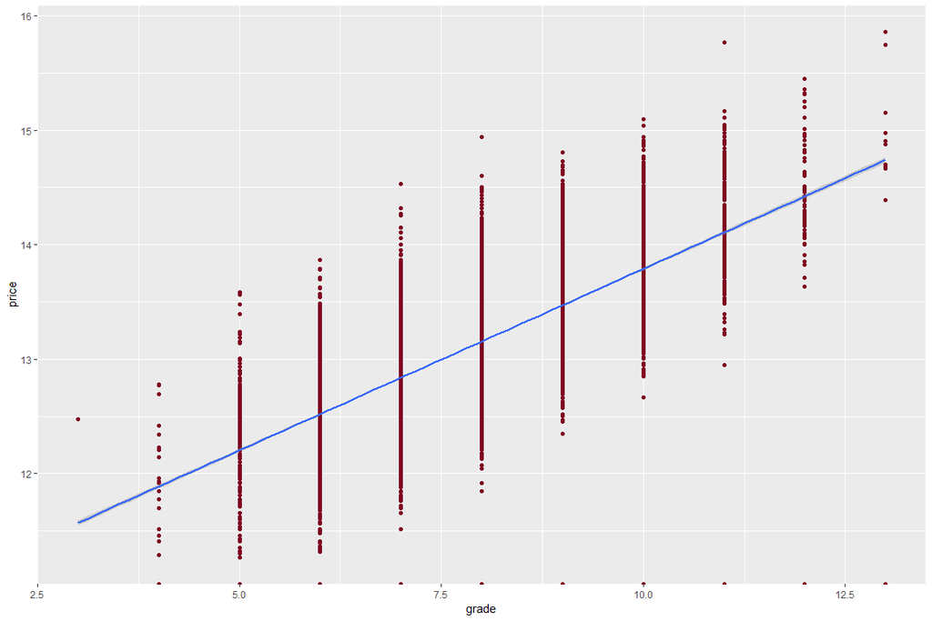

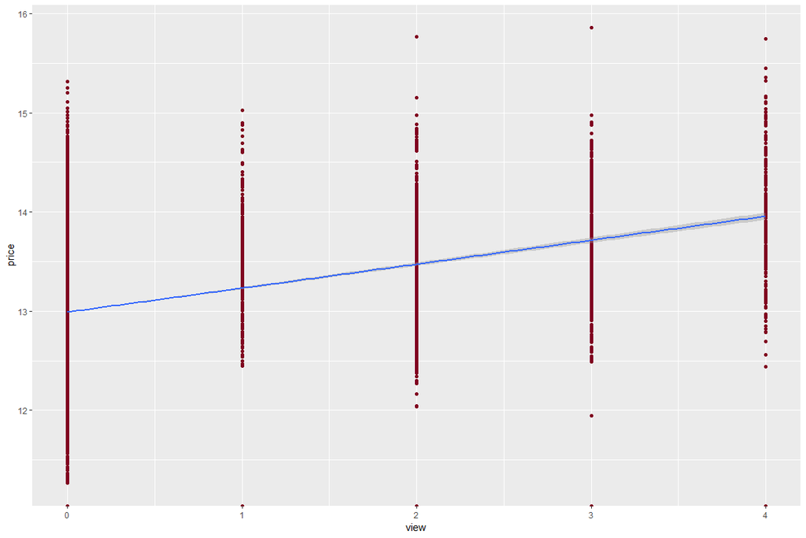

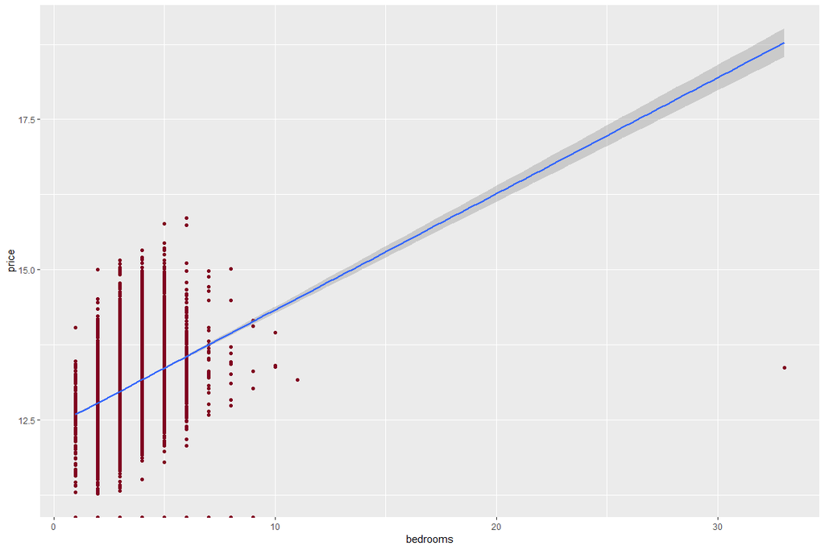

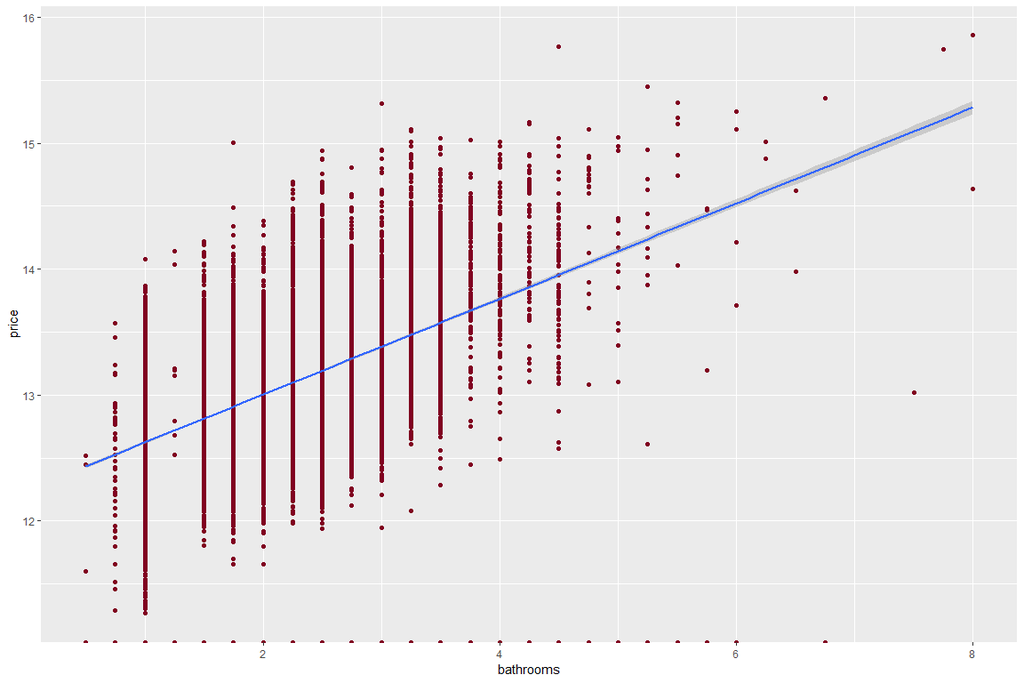

[1 more figures not shown]

# Feature Creation

From the given features, the author came up with some more feature in order to increase the performance of the model.

## Factorizing Variables

When going back to the summary above, one can identify some numerical features which actually are categories. Therefore, those variables will be transformed to factors.

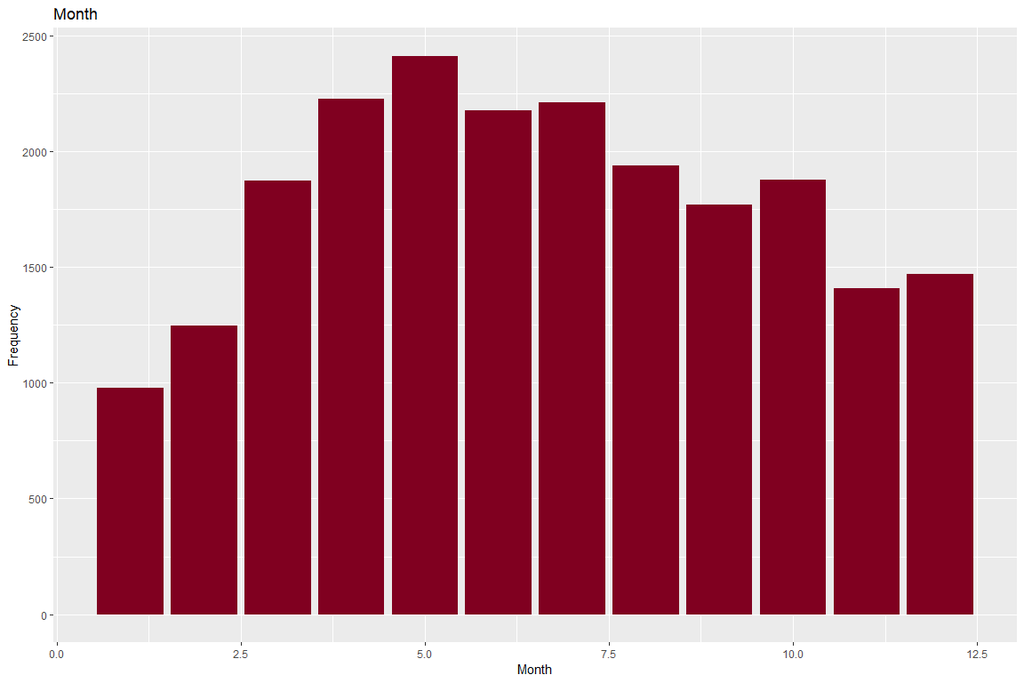

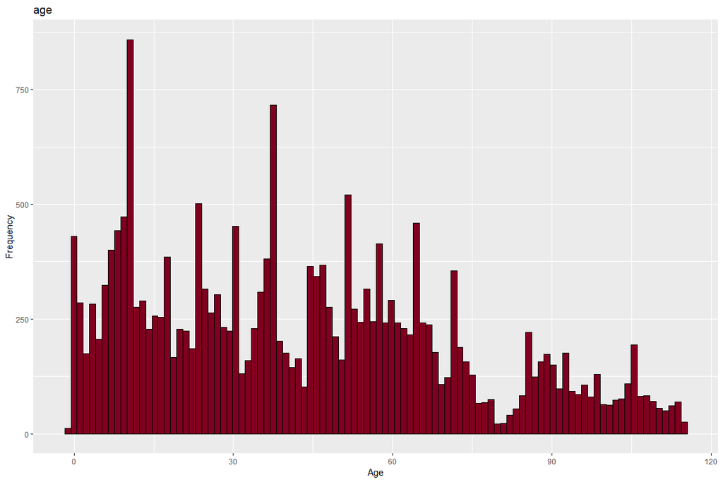

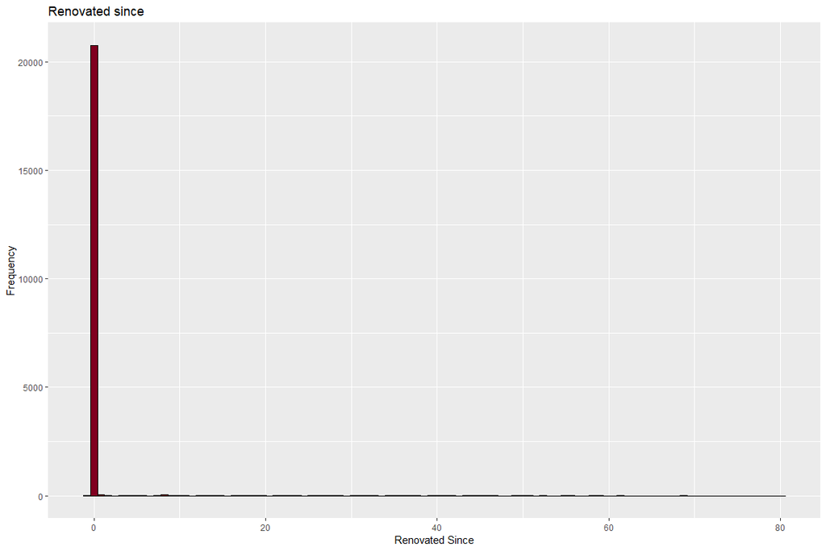

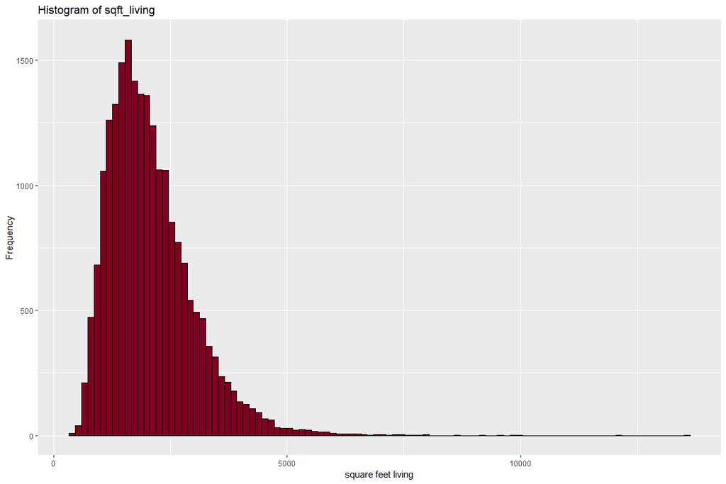

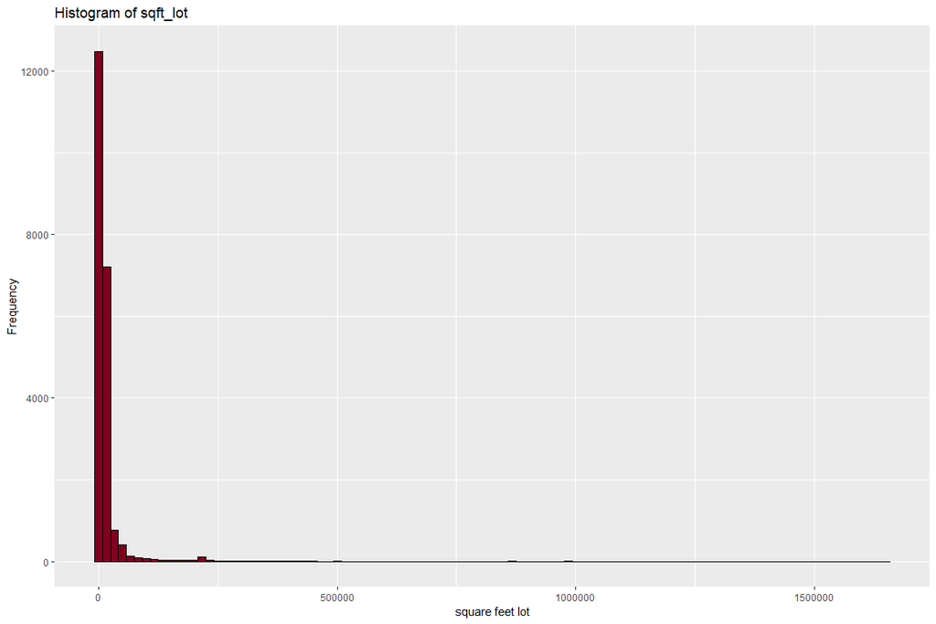